# Postoperative ICU admission on morbidity, length of stay and mortality

# Unadjusted analyses

## Primary outcome: Modified POMS

```r
poms_compos1_unadj <- glm(poms_compos1 ~ icu_adm,
                           data = patients_clean4,
                           family = "binomial")
```

## Secondary outcomes: LOS and mortality

```r
library(MASS)
library(magrittr)
los_unadj <- glm.nb(S07PostopLOS ~ icu_adm, data = patients_clean4)
```

```r
postmort30_unadj <- glm(postmort30 ~ icu_adm,
                          data = patients_clean4,
                          family = "binomial")

postmort60_unadj <- glm(postmort60 ~ icu_adm,
                        data = patients_clean4,
                        family = "binomial")
```

## Exploratory outcomes

### POMS complete

```r
poms_unadj <- glm(POMS ~ icu_adm,
                 data = patients_clean4,
                 family = "binomial")
```

### Each POMS component

```r
poms_cardio_unadj <- glm(POMS_Cardio ~ icu_adm,
                  data = patients_clean4,
                  family = "binomial")

poms_resp_unadj <- glm(POMS_Resp ~ icu_adm,
                  data = patients_clean4,
                  family = "binomial")

poms_renal_unadj <- glm(POMS_Renal ~ icu_adm,
                       data = patients_clean4,
                       family = "binomial")

poms_gastro_unadj <- glm(POMS_Gastro ~ icu_adm,
                       data = patients_clean4,
                       family = "binomial")

poms_inf_unadj <- glm(POMS_Inf ~ icu_adm,
                       data = patients_clean4,
                       family = "binomial")

poms_neuro_unadj <- glm(POMS_Neuro ~ icu_adm,
                       data = patients_clean4,
                       family = "binomial")

poms_haem_unadj <- glm(POMS_Haem ~ icu_adm,
                       data = patients_clean4,
                       family = "binomial")

poms_wound_unadj <- glm(POMS_Wound ~ icu_adm,
                       data = patients_clean4,
                       family = "binomial")

poms_pain_unadj <- glm(POMS_Pain ~ icu_adm,
                       data = patients_clean4,
                       family = "binomial")
```

### “ICU POMS”

```r
poms_cardpulm_unadj <- glm(poms_cardpulm ~ icu_adm,
                       data = patients_clean4,
                       family = "binomial")

poms_cardpulmren_unadj <- glm(poms_cardpulmren ~ icu_adm,
                           data = patients_clean4,
                           family = "binomial")
```

### POMS ordinal

```r
library(MASS)

#Ordinal regression 1
ord_log_poms_compos1_unadj <- polr(poms_compos1_ord ~ icu_adm, data = patients_clean4, Hess=TRUE)

summary(ord_log_poms_compos1_unadj)
ctable_pomsordinal2 <- coef(summary(ord_log_poms_compos1_unadj))
ctable_pomsordinal_p2 <- pnorm(abs(ctable_pomsordinal2[, "t value"]), lower.tail = FALSE) * 2
ctable_pomsordinal2 <- cbind(ctable_pomsordinal2, "p value" = ctable_pomsordinal_p2)
ctable_pomsordinal2

ci_pomsordinal2 <- confint(ord_log_poms_compos1_unadj)
exp(coef(ord_log_poms_compos1_unadj))
exp(cbind(OR = coef(ord_log_poms_compos1_unadj), ci_pomsordinal2))


#Oridnal regression 2
ord_log_poms_unadj <- polr(poms_ordinal ~ icu_adm, data = patients_clean4, Hess=TRUE)

summary(ord_log_poms_unadj)
ctable_pomsordinal <- coef(summary(ord_log_poms_unadj))
ctable_pomsordinal_p <- pnorm(abs(ctable_pomsordinal[, "t value"]), lower.tail = FALSE) * 2
ctable_pomsordinal <- cbind(ctable_pomsordinal, "p value" = ctable_pomsordinal_p)
ctable_pomsordinal

ci_pomsordinal <- confint(ord_log_poms_unadj)
exp(coef(ord_log_poms_unadj))
exp(cbind(OR = coef(ord_log_poms_unadj), ci_pomsordinal))
```

## All Results

### Primary and secondary outcomes

```r
exp(cbind(OR = coef(poms_compos1_unadj), confint(poms_compos1_unadj)))
exp(cbind(OR = coef(los_unadj), confint(los_unadj)))
exp(cbind(OR = coef(postmort30_unadj), confint(postmort30_unadj)))
exp(cbind(OR = coef(postmort60_unadj), confint(postmort60_unadj)))
```

```r
tab_model(poms_compos1_unadj, los_unadj, postmort30_unadj, postmort60_unadj, transform = NULL)
```

|  | poms_compos1 |  |  | S07PostopLOS |  |  | postmort30 |  |  | postmort60 |  |  |
| --- | --- | --- | --- | --- | --- | --- | --- | --- | --- | --- | --- | --- |
| Predictors | Log-Odds | CI | p | Log-Mean | CI | p | Log-Odds | CI | p | Log-Odds | CI | p |
| (Intercept) | -2.51 | -2.56 – -2.46 | **<0.001** | 1.40 | 1.38 – 1.41 | **<0.001** | -5.37 | -5.58 – -5.18 | **<0.001** | -5.21 | -5.40 – -5.03 | **<0.001** |
| icu_admTRUE | 1.63 | 1.52 – 1.74 | **<0.001** | 0.88 | 0.83 – 0.92 | **<0.001** | 1.96 | 1.63 – 2.27 | **<0.001** | 1.85 | 1.55 – 2.15 | **<0.001** |
| Observations | 22748 |  |  | 22620 |  |  | 22762 |  |  | 22761 |  |  |
| R<sup>2</sup> Tjur | 0.045 |  |  | 0.105 |  |  | 0.009 |  |  | 0.008 |  |  |

### Exploratory outcomes

```r
exp(cbind(OR = coef(poms_unadj), confint(poms_unadj)))

exp(cbind(OR = coef(poms_cardio_unadj), confint(poms_cardio_unadj)))
exp(cbind(OR = coef(poms_resp_unadj), confint(poms_resp_unadj)))
exp(cbind(OR = coef(poms_renal_unadj), confint(poms_renal_unadj)))
exp(cbind(OR = coef(poms_gastro_unadj), confint(poms_gastro_unadj)))
exp(cbind(OR = coef(poms_inf_unadj), confint(poms_inf_unadj)))
exp(cbind(OR = coef(poms_neuro_unadj), confint(poms_neuro_unadj)))
exp(cbind(OR = coef(poms_haem_unadj), confint(poms_haem_unadj)))
exp(cbind(OR = coef(poms_wound_unadj), confint(poms_wound_unadj)))
exp(cbind(OR = coef(poms_pain_unadj), confint(poms_pain_unadj)))

exp(cbind(OR = coef(poms_cardpulm_unadj), confint(poms_cardpulm_unadj)))
exp(cbind(OR = coef(poms_cardpulmren_unadj), confint(poms_cardpulmren_unadj)))

#Results of ordinal outcomes see above
```

POMS complete

```r
tab_model(poms_unadj, transform = NULL)
```

|  | POMS |  |  |
| --- | --- | --- | --- |
| Predictors | Log-Odds | CI | p |
| (Intercept) | -2.31 | -2.36 – -2.27 | **<0.001** |
| icu_admTRUE | 1.74 | 1.63 – 1.84 | **<0.001** |
| Observations | 22745 |  |  |
| R<sup>2</sup> Tjur | 0.059 |  |  |

Each POMS component

```r
tab_model(poms_cardio_unadj, poms_resp_unadj, poms_renal_unadj, poms_gastro_unadj,
          poms_inf_unadj, poms_neuro_unadj, poms_haem_unadj, poms_wound_unadj,
          poms_pain_unadj, transform = NULL)
```

|  | POMS_Cardio |  |  | POMS_Resp |  |  | POMS_Renal |  |  | POMS_Gastro |  |  | POMS_Inf |  |  | POMS_Neuro |  |  | POMS_Haem |  |  | POMS_Wound |  |  | POMS_Pain |  |  |
| --- | --- | --- | --- | --- | --- | --- | --- | --- | --- | --- | --- | --- | --- | --- | --- | --- | --- | --- | --- | --- | --- | --- | --- | --- | --- | --- | --- |
| Predictors | Log-Odds | CI | p | Log-Odds | CI | p | Log-Odds | CI | p | Log-Odds | CI | p | Log-Odds | CI | p | Log-Odds | CI | p | Log-Odds | CI | p | Log-Odds | CI | p | Log-Odds | CI | p |
| (Intercept) | -4.75 | -4.91 – -4.61 | **<0.001** | -4.33 | -4.45 – -4.21 | **<0.001** | -3.30 | -3.38 – -3.23 | **<0.001** | -3.91 | -4.01 – -3.82 | **<0.001** | -2.90 | -2.96 – -2.84 | **<0.001** | -4.53 | -4.67 – -4.40 | **<0.001** | -5.81 | -6.07 – -5.57 | **<0.001** | -4.78 | -4.94 – -4.64 | **<0.001** | -3.97 | -4.08 – -3.87 | **<0.001** |
| icu_admTRUE | 2.10 | 1.87 – 2.33 | **<0.001** | 2.24 | 2.06 – 2.43 | **<0.001** | 1.62 | 1.48 – 1.76 | **<0.001** | 1.85 | 1.68 – 2.02 | **<0.001** | 1.52 | 1.40 – 1.65 | **<0.001** | 1.62 | 1.38 – 1.85 | **<0.001** | 1.60 | 1.15 – 2.03 | **<0.001** | 1.14 | 0.82 – 1.45 | **<0.001** | 1.70 | 1.52 – 1.88 | **<0.001** |
| Observations | 22748 |  |  | 22751 |  |  | 22731 |  |  | 22744 |  |  | 22750 |  |  | 22750 |  |  | 22750 |  |  | 22748 |  |  | 22746 |  |  |
| R<sup>2</sup> Tjur | 0.020 |  |  | 0.036 |  |  | 0.027 |  |  | 0.026 |  |  | 0.030 |  |  | 0.010 |  |  | 0.003 |  |  | 0.002 |  |  | 0.019 |  |  |

“ICU POMS”

```r
tab_model(poms_cardpulm_unadj, poms_cardpulmren_unadj, transform = NULL)
```

|  | poms_cardpulm |  |  | poms_cardpulmren |  |  |
| --- | --- | --- | --- | --- | --- | --- |
| Predictors | Log-Odds | CI | p | Log-Odds | CI | p |
| (Intercept) | -3.98 | -4.08 – -3.88 | **<0.001** | -3.04 | -3.10 – -2.97 | **<0.001** |
| icu_admTRUE | 2.19 | 2.03 – 2.35 | **<0.001** | 1.82 | 1.70 – 1.95 | **<0.001** |
| Observations | 22748 |  |  | 22734 |  |  |
| R<sup>2</sup> Tjur | 0.044 |  |  | 0.047 |  |  |

# Confounders

## Overview

The following confounders are not oncluded based on our meeting discussion:

- ECG: unreliable
- SORT Mortality: 30-day mortality risk by perop team already included. SORT components are already used as seprate confounders.
- POSSUm Mortality: 30-day mortality risk by perop team already included.

## Missing values

- Primary outcome: Modified POMS

```r
sum(is.na(patients_clean4$poms_compos1))
## [1] 58
poms_compos1_mis <- which(!complete.cases(patients_clean4$poms_compos1))
```

- Treatment: ICU yes/no

```r
sum(is.na(patients_clean4$icu_adm))
## [1] 138
icu_mis <- which(!complete.cases(patients_clean4$icu_adm))
```

1. Sex

```r
patients_clean4$S01Gender <- as.factor(patients_clean4$S01Gender)
patients_clean4 %>% group_by(S01Gender)  %>% summarise(freq=n())
## # A tibble: 2 x 2
##   S01Gender  freq
##   <fct>     <int>
## 1 F         13862
## 2 M          9044
sum(is.na(patients_clean4$S01Gender))
## [1] 0
gender_mis <- which(!complete.cases(patients_clean4$S01Gender)) #Select all missing values in gender
```

2. Age

```r
patients_clean4$age <- as.integer(patients_clean4$S01Age)
summary(patients_clean4$age) #No extremes
##    Min. 1st Qu.  Median    Mean 3rd Qu.    Max.
##   18.00   36.00   56.00   54.72   71.00  105.00
sum(is.na(patients_clean4$age)) #No missing values
## [1] 0
age_mis <- which(!complete.cases(patients_clean4$age))
```

3. Patient origin: Home/Inaptient

```r
patients_clean4$S02PatientOrigin <- as.factor(patients_clean4$S02PatientOrigin)
sum(is.na(patients_clean4$S02PatientOrigin))
## [1] 0
ptorigin_mis <- which(!complete.cases(patients_clean4$S02PatientOrigin))
```

4. Procedure count: Number of procedures prior to intervention

```r
sum(is.na(patients_clean4$S04ProcedureCount))
## [1] 96
proccount_miss <- which(!complete.cases(patients_clean4$S04ProcedureCount))
```

5. Urgency: emergent / expedited / immediate

```r
patients_clean4$S02OperativeUrgency <- as.factor(patients_clean4$S02OperativeUrgency)
sum(is.na(patients_clean4$S02OperativeUrgency))
## [1] 3
urgency_mis <- which(!complete.cases(patients_clean4$S02OperativeUrgency))
```

6. Procedural Severity

```r
sum(is.na(patients_clean4$S02PlannedProcSeverity))
## [1] 16
procseverity_miss <- which(!complete.cases(patients_clean4$S02PlannedProcSeverity))
```

7. ASA score

```r
patients_clean4$S03AsaPsClass <- as.factor(patients_clean4$S03AsaPsClass)
sum(is.na(patients_clean4$S03AsaPsClass))
## [1] 40
asa_miss <- which(!complete.cases(patients_clean4$S03AsaPsClass)) #recat to low, medium, high later
```

8. General anesthesia: yes/no

```r
sum(is.na(patients_clean4$S04AnaestheticTechniqueGeneral))
## [1] 17
ga_miss <- which(!complete.cases(patients_clean4$S04AnaestheticTechniqueGeneral))
```

9. Level of support

```r
sum(is.na(patients_clean4$S02LevelOfSupport))
## [1] 8
supplev_miss <- which(!complete.cases(patients_clean4$S02LevelOfSupport))
```

10. Preop LOS

```r
sum(is.na(patients_clean4$S02PreopLOS))
## [1] 0
preoplos_miss <- which(!complete.cases(patients_clean4$S02PreopLOS))
```

11. Malignancy

```r
sum(is.na(patients_clean4$S04Malignancy)) #recat to binary later
## [1] 84
malign_miss <- which(!complete.cases(patients_clean4$S04Malignancy))
```

12. Radiological finding

```r
sum(is.na(patients_clean4$S03RadiologicalFindings)) #recat later to 0=false, 1=true
## [1] 23
radio_miss <- which(!complete.cases(patients_clean4$S03RadiologicalFindings))
```

13. CAD

```r
sum(is.na(patients_clean4$S03PastMedicalHistoryCoronaryArteryDisease))
## [1] 15
patients_clean4$S03PastMedicalHistoryCoronaryArteryDisease <- as.factor(patients_clean4$S03PastMedicalHistoryCoronaryArteryDisease)
cad_miss <- which(!complete.cases(patients_clean4$S03PastMedicalHistoryCoronaryArteryDisease)) #recat later 0=false, 1=true
```

14. CHF

```r
sum(is.na(patients_clean4$S03PastMedicalHistoryCongestiveCardiacFailure))
## [1] 17
patients_clean4$S03PastMedicalHistoryCongestiveCardiacFailure <- as.factor(patients_clean4$S03PastMedicalHistoryCongestiveCardiacFailure)
chf_miss <- which(!complete.cases(patients_clean4$S03PastMedicalHistoryCongestiveCardiacFailure)) #recat later 0=false, 1=true
```

15. Stroke

```r
sum(is.na(patients_clean4$S03PastMedicalHistoryStrokeTIA))
## [1] 18
patients_clean4$S03PastMedicalHistoryStrokeTIA <- as.factor(patients_clean4$S03PastMedicalHistoryStrokeTIA)
stroke_miss <- which(!complete.cases(patients_clean4$S03PastMedicalHistoryStrokeTIA)) #recat later 0=false, 1=true
```

16. Dementia

```r
sum(is.na(patients_clean4$S03PastMedicalHistoryDementia))
## [1] 18
patients_clean4$S03PastMedicalHistoryDementia <- as.factor(patients_clean4$S03PastMedicalHistoryDementia)
demen_miss <- which(!complete.cases(patients_clean4$S03PastMedicalHistoryDementia)) #recat later 0=false, 1=true
```

17. COPD

```r
sum(is.na(patients_clean4$S03PastMedicalHistoryCOPD))
## [1] 17
patients_clean4$S03PastMedicalHistoryCOPD <- as.factor(patients_clean4$S03PastMedicalHistoryCOPD)
copd_miss <- which(!complete.cases(patients_clean4$S03PastMedicalHistoryCOPD)) #recat later 0=false, 1=true
```

18. Pulmonary fibrosis

```r
sum(is.na(patients_clean4$S03PastMedicalHistoryPulmonaryFibrosis))
## [1] 19
patients_clean4$S03PastMedicalHistoryPulmonaryFibrosis <- as.factor(patients_clean4$S03PastMedicalHistoryPulmonaryFibrosis)
pulmfibr_miss <- which(!complete.cases(patients_clean4$S03PastMedicalHistoryPulmonaryFibrosis)) #recat later 0=false, 1=true
```

19. Liver cirrhosis

```r
sum(is.na(patients_clean4$S03PastMedicalHistoryLiverCirrhosis))
## [1] 18
patients_clean4$S03PastMedicalHistoryLiverCirrhosis <- as.factor(patients_clean4$S03PastMedicalHistoryLiverCirrhosis)
livcirr_miss <- which(!complete.cases(patients_clean4$S03PastMedicalHistoryLiverCirrhosis)) #recat later 0=false, 1=true
```

20. Renal disease

```r
sum(is.na(patients_clean4$S03PastMedicalHistoryRenalDisease))
## [1] 20
patients_clean4$S03PastMedicalHistoryRenalDisease <- as.factor(patients_clean4$S03PastMedicalHistoryRenalDisease)
ren_miss <- which(!complete.cases(patients_clean4$S03PastMedicalHistoryRenalDisease)) #recat later 0=false, 1=true
```

21. Diabetes

```r
sum(is.na(patients_clean4$S03Diabetes))
## [1] 26
diab_miss <- which(!complete.cases(patients_clean4$S03Diabetes)) #recat later 0=false, 1=true
```

22. Polytrauma

```r
sum(is.na(patients_clean4$S03PastMedicalHistoryComplexPolytrauma))
## [1] 22
patients_clean4$S03PastMedicalHistoryComplexPolytrauma <- as.factor(patients_clean4$S03PastMedicalHistoryComplexPolytrauma)
polytr_miss <- which(!complete.cases(patients_clean4$S03PastMedicalHistoryComplexPolytrauma)) #recat later 0=false, 1=true
```

23. Preop GCS

```r
sum(is.na(patients_clean4$S03GlasgowComaScaleGcsPreInductionOfAnaesthesia))
## [1] 71
preopGCS_miss <- which(!complete.cases(patients_clean4$S03GlasgowComaScaleGcsPreInductionOfAnaesthesia))
```

24. Subjective assesment of 30-d mortality (periop team)

```r
sum(is.na(patients_clean4$S03PerioperativeTeamOfTheRiskOfDeathWithin30Days))
## [1] 382
mort30d_miss <- which(!complete.cases(patients_clean4$S03PerioperativeTeamOfTheRiskOfDeathWithin30Days)) #recat later
```

25. Systolic blood pressure

```r
sum(is.na(patients_clean4$S03SystolicBloodPressureBpAtPreAssessment))
## [1] 263
sbp_miss <- which(!complete.cases(patients_clean4$S03SystolicBloodPressureBpAtPreAssessment))
```

26. Heart rate

```r
sum(is.na(patients_clean4$S03PulseRateAtPreoperativeAssessment))
## [1] 289
hr_miss <- which(!complete.cases(patients_clean4$S03PulseRateAtPreoperativeAssessment))
```

27. Dyspnea

```r
sum(is.na(patients_clean4$S03Dyspnoea))
## [1] 108
dyspnea_miss <- which(!complete.cases(patients_clean4$S03Dyspnoea)) #recat later
```

28. Night surgery: yes/no

```r
sum(is.na(patients_clean4$S02TimeOfSurgeryStartIncision))
## [1] 11
night_miss <- which(!complete.cases(patients_clean4$S02TimeOfSurgeryStartIncision)) #recat later to binary night vs. day
```

29. Anesthetist grade

```r
sum(is.na(patients_clean4$S03GradeOfMostSeniorAnaesthetistPresent))
## [1] 29
anesgrade_miss <- which(!complete.cases(patients_clean4$S03GradeOfMostSeniorAnaesthetistPresent)) #recat later based on expert grade
```

30. Surgeon grade

```r
sum(is.na(patients_clean4$S03GradeOfMostSeniorSurgeonPresent))
## [1] 29
surggrade_miss <- which(!complete.cases(patients_clean4$S03GradeOfMostSeniorSurgeonPresent)) #recat later based on expert grade
```

(31. Instrument: ICU occupancy)

```r
sum(is.na(patients_clean4$CCUCapacityTimeofSurgery))
## [1] 47
occu_miss <- which(!complete.cases(patients_clean4$CCUCapacityTimeofSurgery))
```

Not used anymore based on discussion (see above):

```r
ecg_miss <- which(!complete.cases(patients_clean4$ecg))
sort_miss <- which(!complete.cases(patients_clean4$SORT_mort))
possum_miss <- which(!complete.cases(patients_clean4$pPOSSUM_mort))
```

Drop patients with missing values and store in patients_clean5.

```r
patients_clean5 <- patients_clean4[c(-poms_compos1_mis, -icu_mis, -gender_mis, -age_mis, -ptorigin_mis, -proccount_miss,
                                     -urgency_mis, -procseverity_miss, -asa_miss, -ga_miss, -supplev_miss, -preoplos_miss,
                                     - malign_miss, -radio_miss, -cad_miss, -chf_miss, -stroke_miss, -demen_miss,
                                     -copd_miss, -pulmfibr_miss, -livcirr_miss, -ren_miss, -diab_miss, -polytr_miss,
                                     -preopGCS_miss, -mort30d_miss, -sbp_miss, -hr_miss, -dyspnea_miss, -night_miss,
                                     - anesgrade_miss, -surggrade_miss, -occu_miss
                                      ), ]
```

## Cross-tabulation. Histogram. Recategorisation.

- Treatment: ICU yes/no

```r
xtabs (~ poms_compos1 + icu_adm, data = patients_clean5)
##             icu_adm
## poms_compos1 FALSE  TRUE
##            0 18486  1385
##            1  1489   575
```

1. Sex

```r
xtabs(~ poms_compos1 + S01Gender, data = patients_clean5)
##             S01Gender
## poms_compos1     F     M
##            0 12217  7654
##            1  1033  1031
```

2. Age

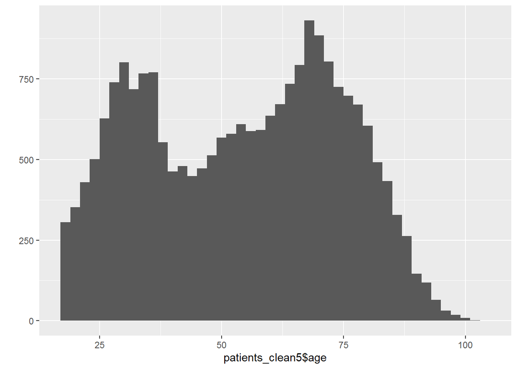

```r
qplot(patients_clean5$age, geom = "histogram", binwidth = 2) #consider recategorization
```

```r
summary(patients_clean5$age)
##    Min. 1st Qu.  Median    Mean 3rd Qu.    Max.
##   18.00   36.00   56.00   54.75   71.00  105.00

#quintiles
patients_clean5$age_p20 <- as.ordered(cut2(patients_clean5$age, g=5))
xtabs(~ poms_compos1 + age_p20, data = patients_clean5)
##             age_p20
## poms_compos1 [18, 34) [34, 50) [50, 64) [64, 75) [75,105]
##            0     4320     4231     3873     3991     3456
##            1      153      235      371      522      783
```

3. Patient origin: Home/Inaptient

```r
xtabs(~ poms_compos1 + S02PatientOrigin, data = patients_clean5)
##             S02PatientOrigin
## poms_compos1     H     I
##            0 13003  6868
##            1   822  1242
```

4. Procedure count: Number of procedures prior to intervention

```r
xtabs(~ poms_compos1 + S04ProcedureCount, data = patients_clean5)
##             S04ProcedureCount
## poms_compos1    >2     1     2   GT2
##            0     4 18484   687   696
##            1     0  1804   158   102
```

5. Urgency: emergent / expedited / immediate

```r
xtabs(~ poms_compos1 + S02OperativeUrgency, data = patients_clean5)
##             S02OperativeUrgency
## poms_compos1   Ele   Exp     I     U
##            0 11264  2429   870  5308
##            1   648   358    95   963

patients_clean5$urg[patients_clean5$S02OperativeUrgency == "Ele"] <- 0
patients_clean5$urg[patients_clean5$S02OperativeUrgency == "Exp"] <- 1
patients_clean5$urg[patients_clean5$S02OperativeUrgency == "U"] <- 2
patients_clean5$urg[patients_clean5$S02OperativeUrgency == "I"] <- 3
patients_clean5$urg <- as.ordered(patients_clean5$urg)
xtabs (~ poms_compos1 + urg, data = patients_clean5)
##             urg
## poms_compos1     0     1     2     3
##            0 11264  2429  5308   870
##            1   648   358   963    95
```

6. Procedural Severity

```r
xtabs(~ poms_compos1 + S02PlannedProcSeverity, data = patients_clean5)
##             S02PlannedProcSeverity
## poms_compos1  Min  Int  Maj  Xma  Com
##            0 1484 3868 8444 3954 2121
##            1  152  267  644  561  440
```

7. ASA score

```r
xtabs(~ poms_compos1 + S03AsaPsClass, data = patients_clean5) #few patients with ASA5 - consider recategorization
##             S03AsaPsClass
## poms_compos1    I   II  III   IV    V
##            0 5590 9403 4339  528   11
##            1  135  720  965  242    2

#ASA high, medium and low
patients_clean5$asa[patients_clean5$S03AsaPsClass == "IV" | patients_clean5$S03AsaPsClass == "V"] <- 2
patients_clean5$asa[patients_clean5$S03AsaPsClass == "III"] <- 1
patients_clean5$asa[patients_clean5$S03AsaPsClass == "I" | patients_clean5$S03AsaPsClass == "II"] <- 0
patients_clean5$asa <- as.ordered(patients_clean5$asa)
xtabs(~ poms_compos1 + asa, data = patients_clean5)
##             asa
## poms_compos1     0     1     2
##            0 14993  4339   539
##            1   855   965   244
```

8. General anesthesia: yes/no

```r
xtabs(~ poms_compos1 + S04AnaestheticTechniqueGeneral, data = patients_clean5)
##             S04AnaestheticTechniqueGeneral
## poms_compos1 FALSE  TRUE
##            0  5713 14158
##            1   388  1676
```

9. Level of support

```r
xtabs(~ poms_compos1 + S02LevelOfSupport, data = patients_clean5)
##             S02LevelOfSupport
## poms_compos1     0     1
##            0 16086  3785
##            1  1327   737
```

10. Preop LOS

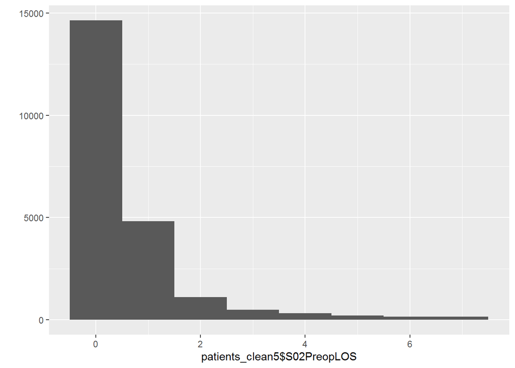

```r
qplot(patients_clean5$S02PreopLOS, geom = "histogram", binwidth = 1)
```

```r
summary(patients_clean5$S02PreopLOS)
##    Min. 1st Qu.  Median    Mean 3rd Qu.    Max.
##  0.0000  0.0000  0.0000  0.5924  1.0000  7.0000
```

11. Malignancy

```r
xtabs(~ poms_compos1 + S04Malignancy, data = patients_clean5)
##             S04Malignancy
## poms_compos1   MDM   MNM    NM    PM
##            0   214   399 17352  1906
##            1    73    91  1666   234

patients_clean5$malig[patients_clean5$S04Malignancy == "MDM"] <- 1
patients_clean5$malig[patients_clean5$S04Malignancy == "MNM"] <- 1
patients_clean5$malig[patients_clean5$S04Malignancy == "PM"] <- 1
patients_clean5$malig[patients_clean5$S04Malignancy == "NM"] <- 0
patients_clean5$malig <- as.factor(patients_clean5$malig)
xtabs (~ poms_compos1 + malig, data = patients_clean5)
##             malig
## poms_compos1     0     1
##            0 17352  2519
##            1  1666   398
```

12. Radiological finding

```r
xtabs(~ poms_compos1 + S03RadiologicalFindings, data = patients_clean5)
##             S03RadiologicalFindings
## poms_compos1  TRUE FALSE
##            0  2244 17627
##            1   673  1391

patients_clean5$radio[patients_clean5$S03RadiologicalFindings == "TRUE"] <- 1
patients_clean5$radio[patients_clean5$S03RadiologicalFindings == "FALSE"] <- 0
patients_clean5$radio <- as.factor(patients_clean5$radio)
xtabs (~ poms_compos1 + radio, data = patients_clean5)
##             radio
## poms_compos1     0     1
##            0 17627  2244
##            1  1391   673
```

13. CAD

```r
xtabs(~ poms_compos1 + S03PastMedicalHistoryCoronaryArteryDisease, data = patients_clean5)
##             S03PastMedicalHistoryCoronaryArteryDisease
## poms_compos1     N     Y
##            0 17903  1968
##            1  1646   418

patients_clean5$cad[patients_clean5$S03PastMedicalHistoryCoronaryArteryDisease == "Y"] <- 1
patients_clean5$cad[patients_clean5$S03PastMedicalHistoryCoronaryArteryDisease == "N"] <- 0
patients_clean5$cad <- as.factor(patients_clean5$cad)
xtabs (~ poms_compos1 + cad, data = patients_clean5)
##             cad
## poms_compos1     0     1
##            0 17903  1968
##            1  1646   418
```

14. CHF

```r
xtabs(~ poms_compos1 + S03PastMedicalHistoryCongestiveCardiacFailure, data = patients_clean5)
##             S03PastMedicalHistoryCongestiveCardiacFailure
## poms_compos1     N     Y
##            0 19361   510
##            1  1921   143

patients_clean5$chf[patients_clean5$S03PastMedicalHistoryCongestiveCardiacFailure == "Y"] <- 1
patients_clean5$chf[patients_clean5$S03PastMedicalHistoryCongestiveCardiacFailure == "N"] <- 0
patients_clean5$chf <- as.factor(patients_clean5$chf)
xtabs (~ poms_compos1 + chf, data = patients_clean5)
##             chf
## poms_compos1     0     1
##            0 19361   510
##            1  1921   143
```

15. Stroke

```r
xtabs(~ poms_compos1 + S03PastMedicalHistoryStrokeTIA, data = patients_clean5)
##             S03PastMedicalHistoryStrokeTIA
## poms_compos1     N     Y
##            0 19012   859
##            1  1887   177

patients_clean5$stroke[patients_clean5$S03PastMedicalHistoryStrokeTIA == "Y"] <- 1
patients_clean5$stroke[patients_clean5$S03PastMedicalHistoryStrokeTIA == "N"] <- 0
patients_clean5$stroke <- as.factor(patients_clean5$stroke)
xtabs (~ poms_compos1 + stroke, data = patients_clean5)
##             stroke
## poms_compos1     0     1
##            0 19012   859
##            1  1887   177
```

16. Dementia

```r
xtabs(~ poms_compos1 + S03PastMedicalHistoryDementia, data = patients_clean5)
##             S03PastMedicalHistoryDementia
## poms_compos1     N     Y
##            0 19501   370
##            1  1893   171

patients_clean5$demen[patients_clean5$S03PastMedicalHistoryDementia == "Y"] <- 1
patients_clean5$demen[patients_clean5$S03PastMedicalHistoryDementia == "N"] <- 0
patients_clean5$demen <- as.factor(patients_clean5$demen)
xtabs (~ poms_compos1 + demen, data = patients_clean5)
##             demen
## poms_compos1     0     1
##            0 19501   370
##            1  1893   171
```

17. COPD

```r
xtabs(~ poms_compos1 + S03PastMedicalHistoryCOPD, data = patients_clean5)
##             S03PastMedicalHistoryCOPD
## poms_compos1     N     Y
##            0 18594  1277
##            1  1760   304

patients_clean5$copd[patients_clean5$S03PastMedicalHistoryCOPD == "Y"] <- 1
patients_clean5$copd[patients_clean5$S03PastMedicalHistoryCOPD == "N"] <- 0
patients_clean5$copd <- as.factor(patients_clean5$copd)
xtabs (~ poms_compos1 + copd, data = patients_clean5)
##             copd
## poms_compos1     0     1
##            0 18594  1277
##            1  1760   304
```

18. Pulmonary fibrosis

```r
xtabs(~ poms_compos1 + S03PastMedicalHistoryPulmonaryFibrosis, data = patients_clean5)
##             S03PastMedicalHistoryPulmonaryFibrosis
## poms_compos1     N     Y
##            0 19757   114
##            1  2042    22

patients_clean5$pulfib[patients_clean5$S03PastMedicalHistoryPulmonaryFibrosis == "Y"] <- 1
patients_clean5$pulfib[patients_clean5$S03PastMedicalHistoryPulmonaryFibrosis == "N"] <- 0
patients_clean5$pulfib <- as.factor(patients_clean5$pulfib)
xtabs (~ poms_compos1 + pulfib, data = patients_clean5)
##             pulfib
## poms_compos1     0     1
##            0 19757   114
##            1  2042    22
```

19. Liver cirrhosis

```r
xtabs(~ poms_compos1 + S03PastMedicalHistoryLiverCirrhosis, data = patients_clean5)
##             S03PastMedicalHistoryLiverCirrhosis
## poms_compos1     N     Y
##            0 19748   123
##            1  2036    28

patients_clean5$livcirr[patients_clean5$S03PastMedicalHistoryLiverCirrhosis == "Y"] <- 1
patients_clean5$livcirr[patients_clean5$S03PastMedicalHistoryLiverCirrhosis == "N"] <- 0
patients_clean5$livcirr <- as.factor(patients_clean5$livcirr)
xtabs (~ poms_compos1 + livcirr, data = patients_clean5)
##             livcirr
## poms_compos1     0     1
##            0 19748   123
##            1  2036    28
```

20. Renal disease

```r
xtabs(~ poms_compos1 + S03PastMedicalHistoryRenalDisease, data = patients_clean5)
##             S03PastMedicalHistoryRenalDisease
## poms_compos1     N     Y
##            0 19634   237
##            1  2013    51

patients_clean5$rend[patients_clean5$S03PastMedicalHistoryRenalDisease == "Y"] <- 1
patients_clean5$rend[patients_clean5$S03PastMedicalHistoryRenalDisease == "N"] <- 0
patients_clean5$rend <- as.factor(patients_clean5$rend)
xtabs (~ poms_compos1 + rend, data = patients_clean5)
##             rend
## poms_compos1     0     1
##            0 19634   237
##            1  2013    51
```

21. Diabetes

```r
xtabs(~ poms_compos1 + S03Diabetes, data = patients_clean5) #recategorize in yes/no
##             S03Diabetes
## poms_compos1     1    2D    2I    2O     N
##            0   209   516   523  1172 17451
##            1    38    74   112   178  1662

#Diabetes yes/no
patients_clean5$diabetfac <- as.factor(patients_clean5$S03Diabetes)
patients_clean5 <- patients_clean5 %>% mutate(diabet = ifelse(diabetfac == "1" | diabetfac == "2D" | diabetfac == "2I" | diabetfac == "2O", 1, 0))
patients_clean5$diabet <- as.factor(patients_clean5$diabet)
xtabs(~ poms_compos1 + diabet, data = patients_clean5)
##             diabet
## poms_compos1     0     1
##            0 17451  2420
##            1  1662   402
```

22. Polytrauma

```r
xtabs(~ poms_compos1 + S03PastMedicalHistoryComplexPolytrauma, data = patients_clean5)
##             S03PastMedicalHistoryComplexPolytrauma
## poms_compos1     N     Y
##            0 19807    64
##            1  2039    25

patients_clean5$polytr[patients_clean5$S03PastMedicalHistoryComplexPolytrauma == "Y"] <- 1
patients_clean5$polytr[patients_clean5$S03PastMedicalHistoryComplexPolytrauma == "N"] <- 0
patients_clean5$polytr <- as.factor(patients_clean5$polytr)
xtabs (~ poms_compos1 + polytr, data = patients_clean5)
##             polytr
## poms_compos1     0     1
##            0 19807    64
##            1  2039    25
```

23. Preop GCS

```r
xtabs(~ poms_compos1 + S03GlasgowComaScaleGcsPreInductionOfAnaesthesia, data = patients_clean5) #recategorize in above and below 8
##             S03GlasgowComaScaleGcsPreInductionOfAnaesthesia
## poms_compos1     3     5     6     7     8     9    10    11    12    13    14
##            0     8     1     2     1     2     3    18     5    15    45   270
##            1     3     0     0     0     1     3     3     4     7    20   131
##             S03GlasgowComaScaleGcsPreInductionOfAnaesthesia
## poms_compos1    15
##            0 19501
##            1  1892

#GCS low or high
patients_clean5 <- patients_clean5 %>% mutate(gcs_low = ifelse(S03GlasgowComaScaleGcsPreInductionOfAnaesthesia <= 8, 1, 0))
patients_clean5$gcs_low <- as.factor(patients_clean5$gcs_low)
xtabs(~ poms_compos1 + gcs_low, data = patients_clean5)
##             gcs_low
## poms_compos1     0     1
##            0 19857    14
##            1  2060     4
```

24. Subjective assesment of 30-d mortality (periop team)

```r
xtabs(~ poms_compos1 + S03PerioperativeTeamOfTheRiskOfDeathWithin30Days, data = patients_clean5)
##             S03PerioperativeTeamOfTheRiskOfDeathWithin30Days
## poms_compos1   G50    L1   L10    L2   L50    L6
##            0    53 15260   495  2954   265   844
##            1    28   709   244   561   190   332

patients_clean5$mort30[patients_clean5$S03PerioperativeTeamOfTheRiskOfDeathWithin30Days == "L1"] <- 0
patients_clean5$mort30[patients_clean5$S03PerioperativeTeamOfTheRiskOfDeathWithin30Days == "L2"] <- 1
patients_clean5$mort30[patients_clean5$S03PerioperativeTeamOfTheRiskOfDeathWithin30Days == "L6"] <- 2
patients_clean5$mort30[patients_clean5$S03PerioperativeTeamOfTheRiskOfDeathWithin30Days == "L10"] <- 3
patients_clean5$mort30[patients_clean5$S03PerioperativeTeamOfTheRiskOfDeathWithin30Days == "L50"] <- 4
patients_clean5$mort30[patients_clean5$S03PerioperativeTeamOfTheRiskOfDeathWithin30Days == "G50"] <- 4
patients_clean5$mort30 <- as.ordered(patients_clean5$mort30)
xtabs (~ poms_compos1 + mort30, data = patients_clean5)
##             mort30
## poms_compos1     0     1     2     3     4
##            0 15260  2954   844   495   318
##            1   709   561   332   244   218
```

25. Systolic blood pressure

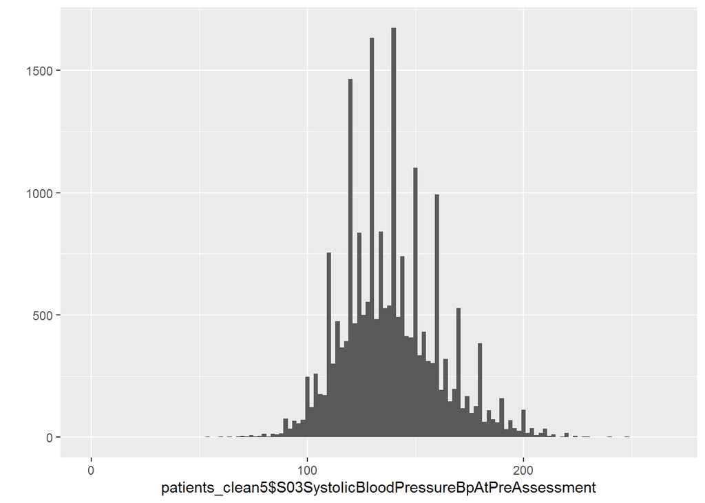

```r
qplot(patients_clean5$S03SystolicBloodPressureBpAtPreAssessment, geom = "histogram", binwidth = 2)
```

```r
summary(patients_clean5$S03SystolicBloodPressureBpAtPreAssessment)
##    Min. 1st Qu.  Median    Mean 3rd Qu.    Max.
##     0.0   123.0   137.0   139.1   152.0   267.0
```

26. Heart rate

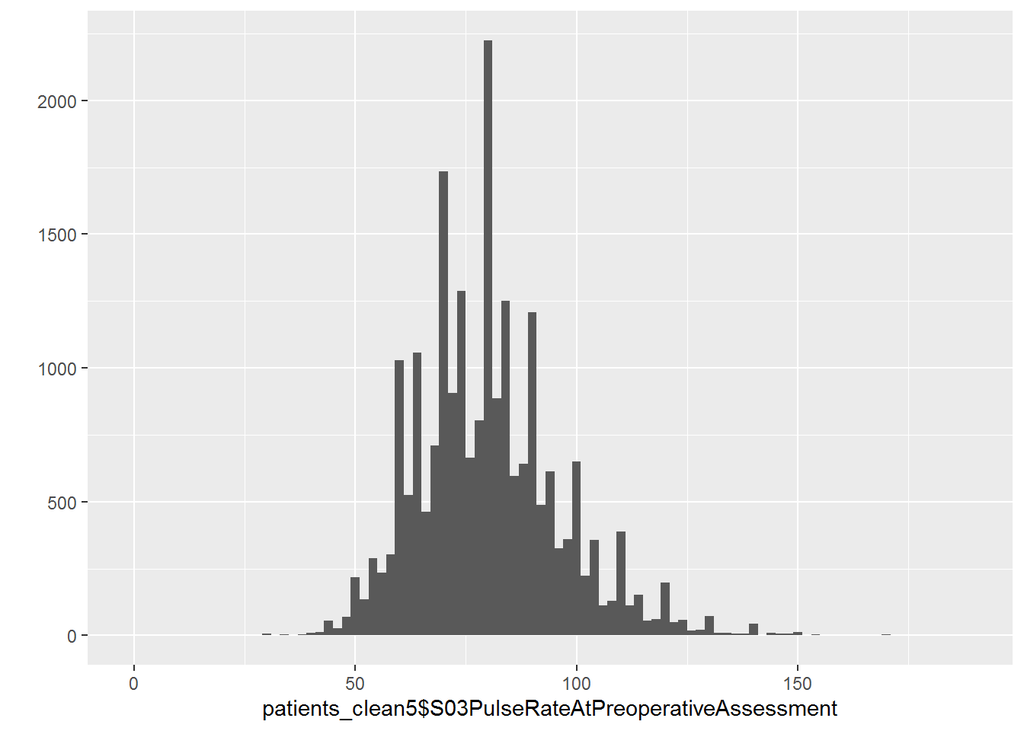

```r
qplot(patients_clean5$S03PulseRateAtPreoperativeAssessment, geom = "histogram", binwidth = 2)
```

```r
summary(patients_clean5$S03PulseRateAtPreoperativeAssessment)
##    Min. 1st Qu.  Median    Mean 3rd Qu.    Max.
##    0.00   70.00   80.00   80.46   90.00  188.00
```

27. Dyspnea

```r
xtabs(~ POMS + S03Dyspnoea, data = patients_clean5)
##        S03Dyspnoea
## POMS       AR     L   Non   OME
##   FALSE   107   789 16230  2327
##   TRUE     76   300  1605   497

patients_clean5$dyspn[patients_clean5$S03Dyspnoea == "Non"] <- 0
patients_clean5$dyspn[patients_clean5$S03Dyspnoea == "OME"] <- 1
patients_clean5$dyspn[patients_clean5$S03Dyspnoea == "L"] <- 2
patients_clean5$dyspn[patients_clean5$S03Dyspnoea == "AR"] <- 2
patients_clean5$dyspn <- as.ordered(patients_clean5$dyspn)
xtabs (~ poms_compos1 + dyspn, data = patients_clean5)
##             dyspn
## poms_compos1     0     1     2
##            0 16483  2415   973
##            1  1355   410   299
```

28. Night surgery: yes/no

```r
patients_clean5$night[patients_clean5$S02TimeOfSurgeryStartIncision == 20] <- 1
patients_clean5$night[patients_clean5$S02TimeOfSurgeryStartIncision == 0] <- 1
patients_clean5$night[patients_clean5$S02TimeOfSurgeryStartIncision == 4] <- 1
patients_clean5$night[patients_clean5$S02TimeOfSurgeryStartIncision == 8] <- 0
patients_clean5$night[patients_clean5$S02TimeOfSurgeryStartIncision == 12] <- 0
patients_clean5$night[patients_clean5$S02TimeOfSurgeryStartIncision == 16] <- 0
patients_clean5$night <- as.factor(patients_clean5$night)
xtabs (~ poms_compos1 + night, data = patients_clean5)
##             night
## poms_compos1     0     1
##            0 18331  1540
##            1  1941   123
```

29. Anesthetist grade

```r
patients_clean5$anesgrade[patients_clean5$S03GradeOfMostSeniorAnaesthetistPresent == "Con"] <- 1
patients_clean5$anesgrade[patients_clean5$S03GradeOfMostSeniorAnaesthetistPresent == "AS"] <- 1
patients_clean5$anesgrade[patients_clean5$S03GradeOfMostSeniorAnaesthetistPresent == "ST3"] <- 2
patients_clean5$anesgrade[patients_clean5$S03GradeOfMostSeniorAnaesthetistPresent == "SR"] <- 2
patients_clean5$anesgrade[patients_clean5$S03GradeOfMostSeniorAnaesthetistPresent == "FEL"] <- 2
patients_clean5$anesgrade[patients_clean5$S03GradeOfMostSeniorAnaesthetistPresent == "CFT"] <- 3
patients_clean5$anesgrade[patients_clean5$S03GradeOfMostSeniorAnaesthetistPresent == "JR"] <- 3
patients_clean5$anesgrade <- as.factor(patients_clean5$anesgrade)
xtabs (~ poms_compos1 + anesgrade, data = patients_clean5)
##             anesgrade
## poms_compos1     1     2     3
##            0 16976  2303   592
##            1  1840   193    31
```

30. Surgeon grade

```r
patients_clean5$surgrade[patients_clean5$S03GradeOfMostSeniorSurgeonPresent == "Con"] <- 1
patients_clean5$surgrade[patients_clean5$S03GradeOfMostSeniorSurgeonPresent == "AS"] <- 1
patients_clean5$surgrade[patients_clean5$S03GradeOfMostSeniorSurgeonPresent == "ST3"] <- 2
patients_clean5$surgrade[patients_clean5$S03GradeOfMostSeniorSurgeonPresent == "SR"] <- 2
patients_clean5$surgrade[patients_clean5$S03GradeOfMostSeniorSurgeonPresent == "FEL"] <- 2
patients_clean5$surgrade[patients_clean5$S03GradeOfMostSeniorSurgeonPresent == "CFT"] <- 3
patients_clean5$surgrade[patients_clean5$S03GradeOfMostSeniorSurgeonPresent == "JR"] <- 3
patients_clean5$surgrade <- as.factor(patients_clean5$surgrade)
xtabs (~ poms_compos1 + surgrade, data = patients_clean5)
##             surgrade
## poms_compos1     1     2     3
##            0 16521  3194   156
##            1  1785   263    16
```

# Adjusted analyses

## Primary outcome: Modified POMS

### “Modified POMS”

```r
log_poms_compos1 <- glm(poms_compos1 ~ icu_adm + S01Gender + age_p20 + S02PatientOrigin + S04ProcedureCount + urg +
                          S02PlannedProcSeverity + asa + S04AnaestheticTechniqueGeneral + S02LevelOfSupport + S02PreopLOS +
                  malig + radio + cad + chf + stroke + demen + copd + pulfib + livcirr + rend + diabet + polytr + gcs_low +
                  mort30 + S03SystolicBloodPressureBpAtPreAssessment + S03PulseRateAtPreoperativeAssessment + dyspn +
                  night + anesgrade + surgrade,
                data = patients_clean5,
                family = "binomial")
```

```r
summary(log_poms_compos1)
exp(cbind(OR = coef(log_poms_compos1), confint(log_poms_compos1)))
```

```r
tab_model(log_poms_compos1, transform = NULL)
```

|  | poms_compos1 |  |  |
| --- | --- | --- | --- |
| Predictors | Log-Odds | CI | p |
| (Intercept) | -12.54 | NA – 5.96 | 0.938 |
| icu_admTRUE | 0.85 | 0.71 – 0.99 | **<0.001** |
| S01Gender [M] | 0.18 | 0.08 – 0.29 | **0.001** |
| age_p20.L | 0.71 | 0.54 – 0.88 | **<0.001** |
| age_p20.Q | -0.11 | -0.25 – 0.02 | 0.097 |
| age_p20.C | 0.07 | -0.05 – 0.20 | 0.243 |
| age_p20^4 | 0.03 | -0.09 – 0.15 | 0.596 |
| S02PatientOrigin [I] | 0.34 | 0.19 – 0.48 | **<0.001** |
| S04ProcedureCount [1] | 9.58 | -8.95 – NA | 0.953 |
| S04ProcedureCount [2] | 9.88 | -8.65 – NA | 0.951 |
| S04ProcedureCount [GT2] | 9.90 | -8.62 – NA | 0.951 |
| urg.L | 0.44 | 0.23 – 0.64 | **<0.001** |
| urg.Q | -0.24 | -0.40 – -0.09 | **0.003** |
| urg.C | -0.09 | -0.20 – 0.03 | 0.136 |
| S02PlannedProcSeverity [Int] | -0.30 | -0.52 – -0.08 | **0.008** |
| S02PlannedProcSeverity [Maj] | -0.14 | -0.34 – 0.07 | 0.185 |
| S02PlannedProcSeverity [Xma] | 0.25 | 0.04 – 0.47 | **0.021** |
| S02PlannedProcSeverity [Com] | 0.21 | -0.02 – 0.44 | 0.081 |
| asa.L | 0.11 | -0.06 – 0.27 | 0.206 |
| asa.Q | -0.19 | -0.30 – -0.09 | **<0.001** |
| S04AnaestheticTechniqueGeneralTRUE | 0.28 | 0.14 – 0.41 | **<0.001** |
| S02LevelOfSupport | 0.19 | 0.07 – 0.31 | **0.002** |
| S02PreopLOS | 0.14 | 0.10 – 0.17 | **<0.001** |
| malig [1] | 0.25 | 0.11 – 0.39 | **<0.001** |
| radio [1] | 0.26 | 0.14 – 0.38 | **<0.001** |
| cad [1] | -0.23 | -0.38 – -0.08 | **0.002** |
| chf [1] | -0.17 | -0.40 – 0.06 | 0.155 |
| stroke [1] | -0.11 | -0.31 – 0.08 | 0.246 |
| demen [1] | 0.36 | 0.14 – 0.59 | **0.001** |
| copd [1] | 0.19 | 0.03 – 0.35 | **0.022** |
| pulfib [1] | -0.21 | -0.75 – 0.28 | 0.412 |
| livcirr [1] | 0.10 | -0.37 – 0.55 | 0.655 |
| rend [1] | 0.23 | -0.12 – 0.56 | 0.179 |
| diabet [1] | 0.15 | 0.01 – 0.28 | **0.033** |
| polytr [1] | 1.01 | 0.48 – 1.52 | **<0.001** |
| gcs_low [1] | -0.63 | -1.99 – 0.53 | 0.317 |
| mort30.L | 0.80 | 0.61 – 0.98 | **<0.001** |
| mort30.Q | -0.46 | -0.61 – -0.31 | **<0.001** |
| mort30.C | 0.11 | -0.03 – 0.25 | 0.121 |
| mort30^4 | 0.06 | -0.07 – 0.20 | 0.352 |
| S03SystolicBloodPressureBpAtPreAssessment | -0.00 | -0.01 – -0.00 | **0.008** |
| S03PulseRateAtPreoperativeAssessment | 0.01 | 0.01 – 0.01 | **<0.001** |
| dyspn.L | 0.02 | -0.11 – 0.15 | 0.787 |
| dyspn.Q | 0.07 | -0.05 – 0.19 | 0.241 |
| night [1] | -0.22 | -0.45 – 0.01 | 0.067 |
| anesgrade [2] | 0.14 | -0.05 – 0.32 | 0.141 |
| anesgrade [3] | -0.24 | -0.65 – 0.13 | 0.219 |
| surgrade [2] | -0.11 | -0.28 – 0.04 | 0.162 |
| surgrade [3] | 0.15 | -0.44 – 0.68 | 0.590 |
| Observations | 21935 |  |  |
| R<sup>2</sup> Tjur | 0.164 |  |  |

## Secondary outcome: LOS

### Postoperative length of stay

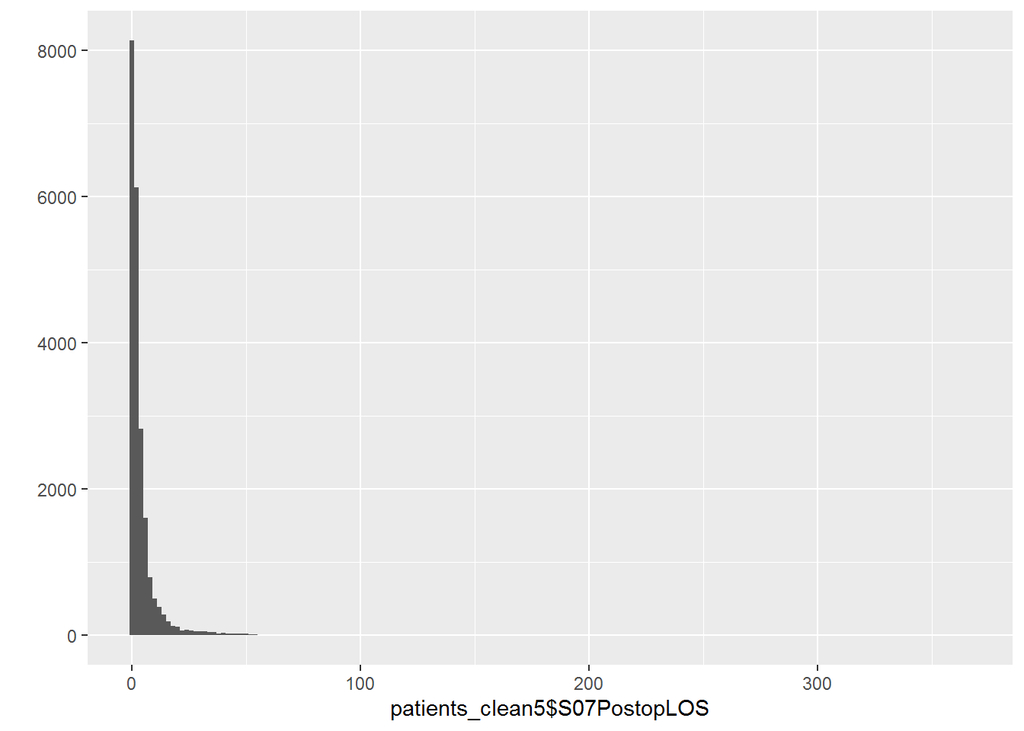

```r
library(MASS)
library(magrittr)

qplot(patients_clean5$S07PostopLOS, geom = "histogram", binwidth = 2)
```

```r
mean(patients_clean5$S07PostopLOS, na.rm=TRUE) %>% round(2); var(patients_clean5$S07PostopLOS, na.rm=TRUE) %>% round(2) #mean and variance
## [1] 4.52
## [1] 60.26
var(patients_clean5$S07PostopLOS, na.rm=TRUE)/mean(patients_clean5$S07PostopLOS, na.rm=TRUE) %>% round(2) #variance ratio, use negative binomial regression
## [1] 13.33096

log_los_compos1 <- glm.nb(S07PostopLOS ~ icu_adm + S01Gender + age_p20 + S02PatientOrigin + S04ProcedureCount + urg +
                    S02PlannedProcSeverity + asa + S04AnaestheticTechniqueGeneral + S02LevelOfSupport + S02PreopLOS +
                    malig + radio + cad + chf + stroke + demen + copd + pulfib + livcirr + rend + diabet + polytr + gcs_low +
                    mort30 + S03SystolicBloodPressureBpAtPreAssessment + S03PulseRateAtPreoperativeAssessment + dyspn +
                    night + anesgrade + surgrade,
                  data = patients_clean5)
```

```r
summary(log_los_compos1)
exp(cbind(IRR = coef(log_los_compos1), confint(log_los_compos1)))
```

```r
tab_model(log_los_compos1, transform = NULL)
```

|  | S07PostopLOS |  |  |
| --- | --- | --- | --- |
| Predictors | Log-Mean | CI | p |
| (Intercept) | 0.58 | -0.45 – 1.62 | 0.261 |
| icu_admTRUE | 0.45 | 0.41 – 0.50 | **<0.001** |
| S01Gender [M] | -0.01 | -0.03 – 0.02 | 0.704 |
| age_p20.L | 0.41 | 0.37 – 0.45 | **<0.001** |
| age_p20.Q | 0.01 | -0.02 – 0.04 | 0.554 |
| age_p20.C | 0.07 | 0.04 – 0.09 | **<0.001** |
| age_p20^4 | -0.00 | -0.03 – 0.03 | 0.975 |
| S02PatientOrigin [I] | 0.22 | 0.19 – 0.26 | **<0.001** |
| S04ProcedureCount [1] | 0.45 | -0.58 – 1.47 | 0.378 |
| S04ProcedureCount [2] | 0.70 | -0.33 – 1.72 | 0.171 |
| S04ProcedureCount [GT2] | 0.59 | -0.44 – 1.61 | 0.250 |
| urg.L | 0.23 | 0.18 – 0.28 | **<0.001** |
| urg.Q | -0.13 | -0.17 – -0.09 | **<0.001** |
| urg.C | -0.02 | -0.05 – 0.01 | 0.155 |
| S02PlannedProcSeverity [Int] | 0.02 | -0.03 – 0.08 | 0.381 |
| S02PlannedProcSeverity [Maj] | 0.26 | 0.21 – 0.31 | **<0.001** |
| S02PlannedProcSeverity [Xma] | 0.54 | 0.49 – 0.60 | **<0.001** |
| S02PlannedProcSeverity [Com] | 0.57 | 0.51 – 0.63 | **<0.001** |
| asa.L | 0.11 | 0.05 – 0.16 | **<0.001** |
| asa.Q | -0.15 | -0.18 – -0.11 | **<0.001** |
| S04AnaestheticTechniqueGeneralTRUE | -0.06 | -0.09 – -0.03 | **<0.001** |
| S02LevelOfSupport | 0.07 | 0.04 – 0.10 | **<0.001** |
| S02PreopLOS | 0.07 | 0.06 – 0.08 | **<0.001** |
| malig [1] | 0.05 | 0.02 – 0.09 | **0.005** |
| radio [1] | 0.18 | 0.14 – 0.21 | **<0.001** |
| cad [1] | -0.09 | -0.13 – -0.05 | **<0.001** |
| chf [1] | 0.01 | -0.07 – 0.08 | 0.885 |
| stroke [1] | 0.06 | 0.01 – 0.12 | **0.027** |
| demen [1] | 0.40 | 0.33 – 0.48 | **<0.001** |
| copd [1] | 0.01 | -0.04 – 0.06 | 0.710 |
| pulfib [1] | -0.07 | -0.21 – 0.08 | 0.378 |
| livcirr [1] | 0.67 | 0.53 – 0.80 | **<0.001** |
| rend [1] | 0.03 | -0.07 – 0.13 | 0.595 |
| diabet [1] | 0.04 | -0.00 – 0.07 | 0.061 |
| polytr [1] | 0.62 | 0.44 – 0.80 | **<0.001** |
| gcs_low [1] | 0.29 | -0.07 – 0.69 | 0.126 |
| mort30.L | 0.40 | 0.34 – 0.46 | **<0.001** |
| mort30.Q | -0.15 | -0.20 – -0.10 | **<0.001** |
| mort30.C | 0.03 | -0.02 – 0.08 | 0.244 |
| mort30^4 | 0.03 | -0.02 – 0.08 | 0.233 |
| S03SystolicBloodPressureBpAtPreAssessment | -0.00 | -0.00 – -0.00 | **0.007** |
| S03PulseRateAtPreoperativeAssessment | 0.00 | 0.00 – 0.00 | **<0.001** |
| dyspn.L | -0.05 | -0.09 – -0.01 | **0.024** |
| dyspn.Q | 0.00 | -0.03 – 0.04 | 0.937 |
| night [1] | -0.07 | -0.13 – -0.02 | **0.011** |
| anesgrade [2] | -0.02 | -0.06 – 0.02 | 0.382 |
| anesgrade [3] | -0.16 | -0.24 – -0.08 | **<0.001** |
| surgrade [2] | -0.09 | -0.13 – -0.06 | **<0.001** |
| surgrade [3] | -0.34 | -0.49 – -0.18 | **<0.001** |
| Observations | 21795 |  |  |
| R<sup>2</sup> Nagelkerke | 0.575 |  |  |

## Secondary outcome: Mortality

### 30-day and 60-day mortality

```r
log_postmort30 <- glm(postmort30 ~ icu_adm + S01Gender + age_p20 + S02PatientOrigin + S04ProcedureCount + urg +
                        S02PlannedProcSeverity + asa + S04AnaestheticTechniqueGeneral + S02LevelOfSupport + S02PreopLOS +
                        malig + radio + cad + chf + stroke + demen + copd + pulfib + livcirr + rend + diabet + polytr + gcs_low +
                        mort30 + S03SystolicBloodPressureBpAtPreAssessment + S03PulseRateAtPreoperativeAssessment + dyspn +
                        night + anesgrade + surgrade,
                  data = patients_clean5,
                  family = "binomial")


log_postmort60 <- glm(postmort60 ~ icu_adm + S01Gender + age_p20 + S02PatientOrigin + S04ProcedureCount + urg +
                        S02PlannedProcSeverity + asa + S04AnaestheticTechniqueGeneral + S02LevelOfSupport + S02PreopLOS +
                        malig + radio + cad + chf + stroke + demen + copd + pulfib + livcirr + rend + diabet + polytr + gcs_low +
                        mort30 + S03SystolicBloodPressureBpAtPreAssessment + S03PulseRateAtPreoperativeAssessment + dyspn +
                        night + anesgrade + surgrade,
                  data = patients_clean5,
                  family = "binomial")
```

```r
summary(log_postmort30)
exp(cbind(OR = coef(log_postmort30 ), confint(log_postmort30 )))

summary(log_postmort60)
exp(cbind(OR = coef(log_postmort60), confint(log_postmort60)))
```

```r
tab_model(log_postmort30, log_postmort60, transform = NULL)
```

|  | postmort30 |  |  | postmort60 |  |  |
| --- | --- | --- | --- | --- | --- | --- |
| Predictors | Log-Odds | CI | p | Log-Odds | CI | p |
| (Intercept) | -14.70 | NA – 582.75 | 0.998 | -14.79 | NA – 579.59 | 0.998 |
| icu_admTRUE | 0.60 | 0.17 – 1.03 | **0.006** | 0.49 | 0.07 – 0.89 | **0.019** |
| S01Gender [M] | 0.45 | 0.09 – 0.82 | **0.014** | 0.51 | 0.17 – 0.85 | **0.003** |
| age_p20.L | 1.80 | 1.01 – 2.71 | **<0.001** | 1.84 | 1.07 – 2.74 | **<0.001** |
| age_p20.Q | 0.58 | -0.19 – 1.29 | 0.115 | 0.43 | -0.33 – 1.10 | 0.229 |
| age_p20.C | -0.21 | -1.06 – 0.51 | 0.582 | -0.24 | -1.08 – 0.47 | 0.526 |
| age_p20^4 | 0.08 | -0.62 – 0.82 | 0.815 | 0.26 | -0.38 – 0.97 | 0.436 |
| S02PatientOrigin [I] | 0.08 | -0.41 – 0.57 | 0.759 | 0.23 | -0.23 – 0.70 | 0.325 |
| S04ProcedureCount [1] | 11.51 | -594.46 – NA | 0.998 | 11.70 | -590.41 – NA | 0.998 |
| S04ProcedureCount [2] | 11.00 | -591.01 – NA | 0.998 | 11.49 | -588.22 – NA | 0.998 |
| S04ProcedureCount [GT2] | 11.49 | -586.52 – NA | 0.998 | 11.78 | -585.18 – NA | 0.998 |
| urg.L | 1.25 | 0.68 – 1.81 | **<0.001** | 1.30 | 0.76 – 1.84 | **<0.001** |
| urg.Q | 0.50 | 0.03 – 0.97 | **0.037** | 0.44 | -0.01 – 0.88 | 0.053 |
| urg.C | 0.10 | -0.30 – 0.48 | 0.606 | 0.17 | -0.21 – 0.52 | 0.368 |
| S02PlannedProcSeverity [Int] | -0.62 | -1.42 – 0.21 | 0.132 | -0.46 | -1.23 – 0.35 | 0.252 |
| S02PlannedProcSeverity [Maj] | -0.24 | -0.90 – 0.50 | 0.509 | -0.06 | -0.71 – 0.67 | 0.874 |
| S02PlannedProcSeverity [Xma] | -0.46 | -1.17 – 0.32 | 0.225 | -0.12 | -0.80 – 0.63 | 0.748 |
| S02PlannedProcSeverity [Com] | -0.41 | -1.18 – 0.41 | 0.312 | -0.27 | -1.03 – 0.53 | 0.493 |
| asa.L | 0.78 | 0.27 – 1.32 | **0.003** | 0.92 | 0.43 – 1.43 | **<0.001** |
| asa.Q | -0.41 | -0.74 – -0.08 | **0.015** | -0.44 | -0.76 – -0.13 | **0.006** |
| S04AnaestheticTechniqueGeneralTRUE | 0.21 | -0.22 – 0.66 | 0.349 | 0.23 | -0.18 – 0.65 | 0.286 |
| S02LevelOfSupport | 0.15 | -0.23 – 0.54 | 0.431 | 0.11 | -0.25 – 0.47 | 0.539 |
| S02PreopLOS | 0.14 | 0.04 – 0.25 | **0.007** | 0.11 | 0.00 – 0.20 | **0.036** |
| malig [1] | -0.01 | -0.54 – 0.48 | 0.958 | 0.07 | -0.41 – 0.53 | 0.766 |
| radio [1] | -0.06 | -0.44 – 0.31 | 0.758 | -0.02 | -0.37 – 0.33 | 0.921 |
| cad [1] | -0.25 | -0.66 – 0.15 | 0.227 | -0.33 | -0.72 – 0.05 | 0.096 |
| chf [1] | 0.05 | -0.48 – 0.57 | 0.841 | 0.07 | -0.44 – 0.55 | 0.796 |
| stroke [1] | 0.38 | -0.12 – 0.84 | 0.124 | 0.42 | -0.05 – 0.85 | 0.067 |
| demen [1] | -0.05 | -0.61 – 0.48 | 0.855 | -0.20 | -0.74 – 0.30 | 0.444 |
| copd [1] | -0.09 | -0.56 – 0.34 | 0.679 | -0.02 | -0.45 – 0.38 | 0.909 |
| pulfib [1] | 0.39 | -0.86 – 1.36 | 0.482 | 0.48 | -0.63 – 1.38 | 0.336 |
| livcirr [1] | 1.25 | 0.23 – 2.11 | **0.009** | 1.11 | 0.11 – 1.96 | **0.018** |
| rend [1] | -0.49 | -1.94 – 0.58 | 0.433 | -0.30 | -1.54 – 0.66 | 0.581 |
| diabet [1] | 0.47 | 0.06 – 0.86 | **0.021** | 0.40 | 0.01 – 0.77 | **0.039** |
| polytr [1] | 1.35 | -0.68 – 2.83 | 0.119 | 1.10 | -0.94 – 2.59 | 0.206 |
| gcs_low [1] | -0.05 | -1.96 – 1.62 | 0.959 | 0.59 | -1.17 – 2.17 | 0.487 |
| mort30.L | 1.63 | 1.10 – 2.18 | **<0.001** | 1.57 | 1.07 – 2.08 | **<0.001** |
| mort30.Q | 0.21 | -0.24 – 0.67 | 0.355 | 0.24 | -0.17 – 0.66 | 0.249 |
| mort30.C | -0.15 | -0.56 – 0.26 | 0.484 | -0.13 | -0.53 – 0.25 | 0.506 |
| mort30^4 | -0.12 | -0.58 – 0.31 | 0.585 | 0.01 | -0.41 – 0.41 | 0.969 |
| S03SystolicBloodPressureBpAtPreAssessment | -0.02 | -0.03 – -0.01 | **<0.001** | -0.02 | -0.03 – -0.01 | **<0.001** |
| S03PulseRateAtPreoperativeAssessment | 0.01 | -0.00 – 0.02 | 0.199 | 0.00 | -0.01 – 0.01 | 0.372 |
| dyspn.L | 0.43 | 0.09 – 0.76 | **0.012** | 0.39 | 0.07 – 0.70 | **0.016** |
| dyspn.Q | 0.21 | -0.13 – 0.56 | 0.245 | 0.14 | -0.17 – 0.48 | 0.381 |
| night [1] | -0.32 | -1.05 – 0.35 | 0.367 | -0.42 | -1.15 – 0.24 | 0.233 |
| anesgrade [2] | 0.34 | -0.35 – 0.96 | 0.307 | 0.20 | -0.48 – 0.81 | 0.536 |
| anesgrade [3] | -13.36 | -168.60 – -153.94 | 0.972 | -13.52 | -173.24 – -264.51 | 0.971 |
| surgrade [2] | -0.01 | -0.56 – 0.51 | 0.978 | -0.03 | -0.55 – 0.46 | 0.908 |
| surgrade [3] | 0.25 | -2.69 – 1.93 | 0.818 | 0.04 | -2.89 – 1.73 | 0.967 |
| Observations | 21930 |  |  | 21929 |  |  |
| R<sup>2</sup> Tjur | 0.139 |  |  | 0.142 |  |  |

```r
#predicted probability for mortality
val.prob(p = predict(log_postmort30, type = "response", newdata = patients_clean5), y = (patients_clean5)$icu_adm)
val.prob(p = predict(log_postmort60, type = "response", newdata = patients_clean5), y = (patients_clean5)$icu_adm)
```

## Exploratory outcomes

Complete POMS

```r
log_poms_all <- glm(POMS ~ icu_adm + S01Gender + age_p20 + S02PatientOrigin + S04ProcedureCount + urg +
                       S02PlannedProcSeverity + asa + S04AnaestheticTechniqueGeneral + S02LevelOfSupport + S02PreopLOS +
                       malig + radio + cad + chf + stroke + demen + copd + pulfib + livcirr + rend + diabet + polytr + gcs_low +
                       mort30 + S03SystolicBloodPressureBpAtPreAssessment + S03PulseRateAtPreoperativeAssessment + dyspn +
                       night + anesgrade + surgrade,
                     data = patients_clean5,
                     family = "binomial")
summary(log_poms_all)
exp(cbind(OR = coef(log_poms_all), confint(log_poms_all)))
```

POMS inherent to ICU

```r
log_poms_cardpulmren <- glm(poms_cardpulmren ~ icu_adm + S01Gender + age_p20 + S02PatientOrigin + S04ProcedureCount + urg +
                          S02PlannedProcSeverity + asa + S04AnaestheticTechniqueGeneral + S02LevelOfSupport + S02PreopLOS +
                          malig + radio + cad + chf + stroke + demen + copd + pulfib + livcirr + rend + diabet + polytr + gcs_low +
                          mort30 + S03SystolicBloodPressureBpAtPreAssessment + S03PulseRateAtPreoperativeAssessment + dyspn +
                          night + anesgrade + surgrade,
                        data = patients_clean5,
                        family = "binomial")
summary(log_poms_cardpulmren)
exp(cbind(OR = coef(log_poms_cardpulmren), confint(log_poms_cardpulmren)))
```

Each single POMS component

```r
log_poms_cardio <- glm(POMS_Cardio ~ icu_adm + S01Gender + age_p20 + S02PatientOrigin + S04ProcedureCount + urg +
                              S02PlannedProcSeverity + asa + S04AnaestheticTechniqueGeneral + S02LevelOfSupport + S02PreopLOS +
                              malig + radio + cad + chf + stroke + demen + copd + pulfib + livcirr + rend + diabet + polytr + gcs_low +
                              mort30 + S03SystolicBloodPressureBpAtPreAssessment + S03PulseRateAtPreoperativeAssessment + dyspn +
                              night + anesgrade + surgrade,
                            data = patients_clean5,
                            family = "binomial")
summary(log_poms_cardio)
exp(cbind(OR = coef(log_poms_cardio), confint(log_poms_cardio)))

log_poms_resp <- glm(POMS_Resp ~ icu_adm + S01Gender + age_p20 + S02PatientOrigin + S04ProcedureCount + urg +
                         S02PlannedProcSeverity + asa + S04AnaestheticTechniqueGeneral + S02LevelOfSupport + S02PreopLOS +
                         malig + radio + cad + chf + stroke + demen + copd + pulfib + livcirr + rend + diabet + polytr + gcs_low +
                         mort30 + S03SystolicBloodPressureBpAtPreAssessment + S03PulseRateAtPreoperativeAssessment + dyspn +
                         night + anesgrade + surgrade,
                       data = patients_clean5,
                       family = "binomial")
summary(log_poms_resp)
exp(cbind(OR = coef(log_poms_resp), confint(log_poms_resp)))

log_poms_ren <- glm(POMS_Renal ~ icu_adm + S01Gender + age_p20 + S02PatientOrigin + S04ProcedureCount + urg +
                       S02PlannedProcSeverity + asa + S04AnaestheticTechniqueGeneral + S02LevelOfSupport + S02PreopLOS +
                       malig + radio + cad + chf + stroke + demen + copd + pulfib + livcirr + rend + diabet + polytr + gcs_low +
                       mort30 + S03SystolicBloodPressureBpAtPreAssessment + S03PulseRateAtPreoperativeAssessment + dyspn +
                       night + anesgrade + surgrade,
                     data = patients_clean5,
                     family = "binomial")
summary(log_poms_ren)
exp(cbind(OR = coef(log_poms_ren), confint(log_poms_ren)))

log_poms_gastro <- glm(POMS_Gastro ~ icu_adm + S01Gender + age_p20 + S02PatientOrigin + S04ProcedureCount + urg +
                      S02PlannedProcSeverity + asa + S04AnaestheticTechniqueGeneral + S02LevelOfSupport + S02PreopLOS +
                      malig + radio + cad + chf + stroke + demen + copd + pulfib + livcirr + rend + diabet + polytr + gcs_low +
                      mort30 + S03SystolicBloodPressureBpAtPreAssessment + S03PulseRateAtPreoperativeAssessment + dyspn +
                      night + anesgrade + surgrade,
                    data = patients_clean5,
                    family = "binomial")
summary(log_poms_gastro)
exp(cbind(OR = coef(log_poms_gastro), confint(log_poms_gastro)))

log_poms_inf <- glm(POMS_Inf ~ icu_adm + S01Gender + age_p20 + S02PatientOrigin + S04ProcedureCount + urg +
                         S02PlannedProcSeverity + asa + S04AnaestheticTechniqueGeneral + S02LevelOfSupport + S02PreopLOS +
                         malig + radio + cad + chf + stroke + demen + copd + pulfib + livcirr + rend + diabet + polytr + gcs_low +
                         mort30 + S03SystolicBloodPressureBpAtPreAssessment + S03PulseRateAtPreoperativeAssessment + dyspn +
                         night + anesgrade + surgrade,
                       data = patients_clean5,
                       family = "binomial")
summary(log_poms_inf)
exp(cbind(OR = coef(log_poms_inf), confint(log_poms_inf)))

log_poms_neuro <- glm(POMS_Neuro ~ icu_adm + S01Gender + age_p20 + S02PatientOrigin + S04ProcedureCount + urg +
                      S02PlannedProcSeverity + asa + S04AnaestheticTechniqueGeneral + S02LevelOfSupport + S02PreopLOS +
                      malig + radio + cad + chf + stroke + demen + copd + pulfib + livcirr + rend + diabet + polytr + gcs_low +
                      mort30 + S03SystolicBloodPressureBpAtPreAssessment + S03PulseRateAtPreoperativeAssessment + dyspn +
                      night + anesgrade + surgrade,
                    data = patients_clean5,
                    family = "binomial")
summary(log_poms_neuro)
exp(cbind(OR = coef(log_poms_neuro), confint(log_poms_neuro)))

log_poms_haem <- glm(POMS_Haem ~ icu_adm + S01Gender + age_p20 + S02PatientOrigin + S04ProcedureCount + urg +
                        S02PlannedProcSeverity + asa + S04AnaestheticTechniqueGeneral + S02LevelOfSupport + S02PreopLOS +
                        malig + radio + cad + chf + stroke + demen + copd + pulfib + livcirr + rend + diabet + polytr + gcs_low +
                        mort30 + S03SystolicBloodPressureBpAtPreAssessment + S03PulseRateAtPreoperativeAssessment + dyspn +
                        night + anesgrade + surgrade,
                      data = patients_clean5,
                      family = "binomial")
summary(log_poms_haem)
exp(cbind(OR = coef(log_poms_haem), confint(log_poms_haem)))

log_poms_wound <- glm(POMS_Wound ~ icu_adm + S01Gender + age_p20 + S02PatientOrigin + S04ProcedureCount + urg +
                       S02PlannedProcSeverity + asa + S04AnaestheticTechniqueGeneral + S02LevelOfSupport + S02PreopLOS +
                       malig + radio + cad + chf + stroke + demen + copd + pulfib + livcirr + rend + diabet + polytr + gcs_low +
                       mort30 + S03SystolicBloodPressureBpAtPreAssessment + S03PulseRateAtPreoperativeAssessment + dyspn +
                       night + anesgrade + surgrade,
                     data = patients_clean5,
                     family = "binomial")
summary(log_poms_wound)
exp(cbind(OR = coef(log_poms_wound), confint(log_poms_wound)))

log_poms_pain <- glm(POMS_Pain ~ icu_adm + S01Gender + age_p20 + S02PatientOrigin + S04ProcedureCount + urg +
                        S02PlannedProcSeverity + asa + S04AnaestheticTechniqueGeneral + S02LevelOfSupport + S02PreopLOS +
                        malig + radio + cad + chf + stroke + demen + copd + pulfib + livcirr + rend + diabet + polytr + gcs_low +
                        mort30 + S03SystolicBloodPressureBpAtPreAssessment + S03PulseRateAtPreoperativeAssessment + dyspn +
                        night + anesgrade + surgrade,
                      data = patients_clean5,
                      family = "binomial")
summary(log_poms_pain)
exp(cbind(OR = coef(log_poms_pain), confint(log_poms_pain)))
```

## Regression diagnostics: Primary outcome

### Predicted probability

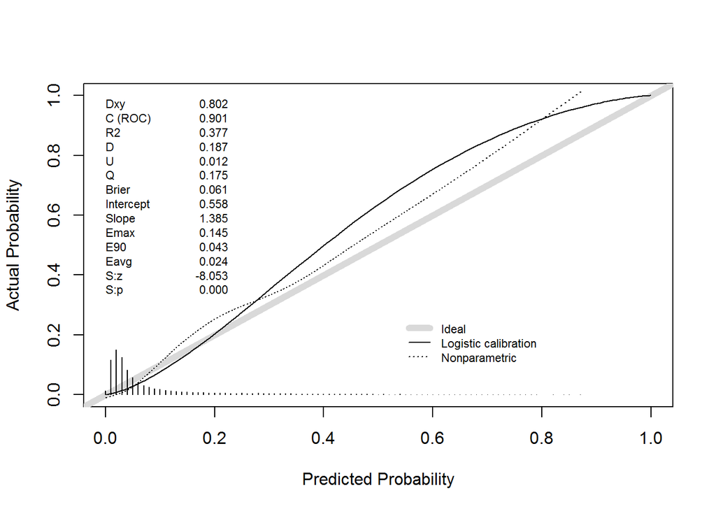

```
##           Dxy       C (ROC)            R2             D      D:Chi-sq
##  8.016516e-01  9.008258e-01  3.774819e-01  1.871845e-01  4.106891e+03
##           D:p             U      U:Chi-sq           U:p             Q
##            NA  1.217008e-02  2.689508e+02  0.000000e+00  1.750144e-01
##         Brier     Intercept         Slope          Emax           E90
##  6.055095e-02  5.580934e-01  1.385375e+00  1.447127e-01  4.274905e-02
##          Eavg           S:z           S:p
##  2.409555e-02 -8.052769e+00  8.094128e-16
```

```r
val.prob(p = predict(log_poms_compos1, type = "response", newdata = patients_clean5), y = (patients_clean5)$icu_adm)
```

### Goodness of fit (Hosmer Lemeshow test)

```r
library(ResourceSelection)
hos_poms_compos1 <- hoslem.test(patients_clean5$poms_compos1, fitted(log_poms_compos1), g=10)
hos_poms_compos1 #p<0.05 which means: no good model fit
##
##  Hosmer and Lemeshow goodness of fit (GOF) test
##
## data:  patients_clean5$poms_compos1, fitted(log_poms_compos1)
## X-squared = 43.697, df = 8, p-value = 6.492e-07
```

### Influential values

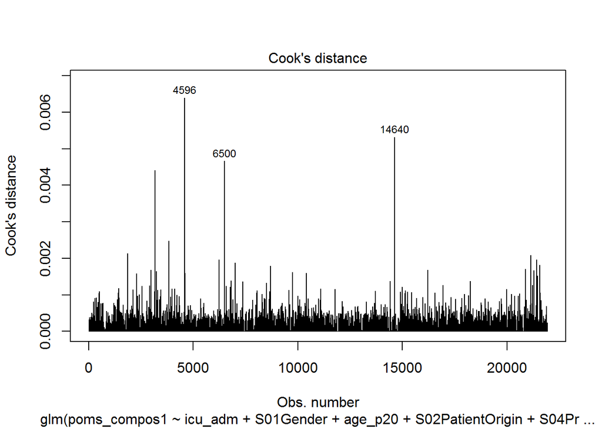

```r
library(broom)
theme_set(theme_classic())

plot(log_poms_compos1, which = 4, id.n = 3) #3 most extreme values in data
```

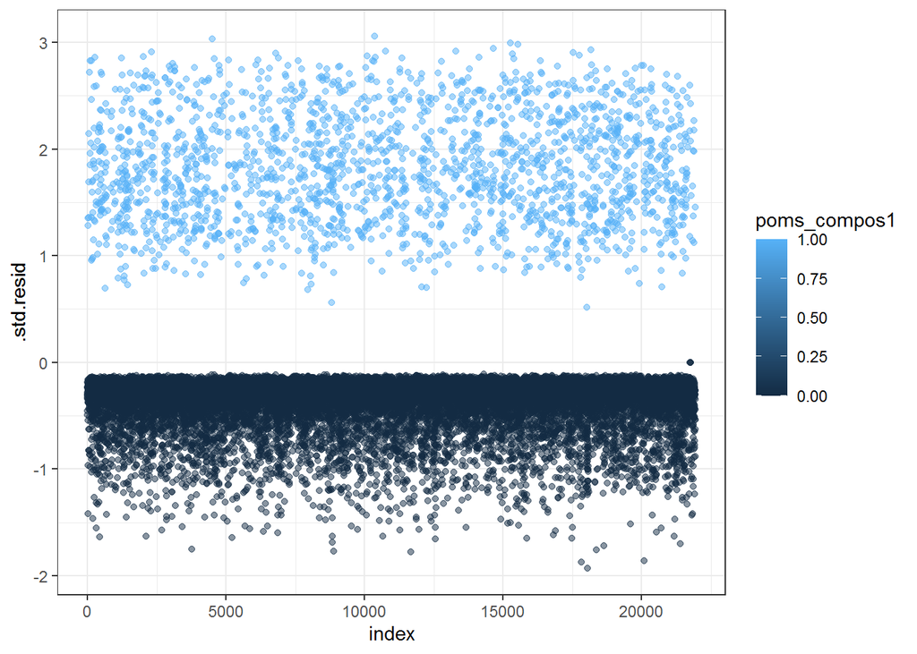

```r
model.data <- augment(log_poms_compos1) %>% mutate(index = 1:n()) #compute standardized residuals and Cook's distance
model.data %>% top_n(3, .cooksd) #top 3 Cook's distances
## # A tibble: 3 x 40
##   poms_compos1 icu_adm S01Gender age_p20 S02PatientOrigin S04ProcedureCou~ urg
##          <dbl> <lgl>   <fct>     <ord>   <fct>            <chr>            <ord>
## 1            1 TRUE    M         [50, 6~ H                1                3
## 2            0 TRUE    F         [75,10~ I                1                3
## 3            1 FALSE   F         [75,10~ H                1                2
## # ... with 33 more variables: S02PlannedProcSeverity <fct>, asa <ord>,
## #   S04AnaestheticTechniqueGeneral <lgl>, S02LevelOfSupport <int>,
## #   S02PreopLOS <int>, malig <fct>, radio <fct>, cad <fct>, chf <fct>,
## #   stroke <fct>, demen <fct>, copd <fct>, pulfib <fct>, livcirr <fct>,
## #   rend <fct>, diabet <fct>, polytr <fct>, gcs_low <fct>, mort30 <ord>,
## #   S03SystolicBloodPressureBpAtPreAssessment <int>,
## #   S03PulseRateAtPreoperativeAssessment <int>, dyspn <ord>, night <fct>,
## #   anesgrade <fct>, surgrade <fct>, .fitted <dbl>, .se.fit <dbl>,
## #   .resid <dbl>, .hat <dbl>, .sigma <dbl>, .cooksd <dbl>, .std.resid <dbl>,
## #   index <int>
model.data2 <- model.data %>% filter(abs(.std.resid) > 3) #Select outliers that are stand. residuals >3

ggplot(model.data, aes(index, .std.resid)) +  geom_point(aes(color = poms_compos1), alpha = .5) + theme_bw() #Plot standardized residuals
```